# Explore_titanic_survival

```python
%matplotlib inline
import pandas as pd
import numpy as np
import matplotlib.pyplot as plt
#matplotlib inline -your matplot graph will include in your notebook next to your code
```

Load Data

```python
df=pd.read_csv('train.csv')
df.head()
```

|  | PassengerId | Survived | Pclass | Name | Sex | Age | SibSp | Parch | Ticket | Fare | Cabin | Embarked |
| --- | --- | --- | --- | --- | --- | --- | --- | --- | --- | --- | --- | --- |
| 0 | 1 | 0 | 3 | Braund, Mr. Owen Harris | male | 22.0 | 1 | 0 | A/5 21171 | 7.2500 | NaN | S |
| 1 | 2 | 1 | 1 | Cumings, Mrs. John Bradley (Florence Briggs Th... | female | 38.0 | 1 | 0 | PC 17599 | 71.2833 | C85 | C |
| 2 | 3 | 1 | 3 | Heikkinen, Miss. Laina | female | 26.0 | 0 | 0 | STON/O2. 3101282 | 7.9250 | NaN | S |
| 3 | 4 | 1 | 1 | Futrelle, Mrs. Jacques Heath (Lily May Peel) | female | 35.0 | 1 | 0 | 113803 | 53.1000 | C123 | S |
| 4 | 5 | 0 | 3 | Allen, Mr. William Henry | male | 35.0 | 0 | 0 | 373450 | 8.0500 | NaN | S |

shape of data

```python
df.shape
```

```
(891, 12)
```

Summary Statistics of Data

```python
df.describe()
```

|  | PassengerId | Survived | Pclass | Age | SibSp | Parch | Fare |
| --- | --- | --- | --- | --- | --- | --- | --- |
| count | 891.000000 | 891.000000 | 891.000000 | 714.000000 | 891.000000 | 891.000000 | 891.000000 |
| mean | 446.000000 | 0.383838 | 2.308642 | 29.699118 | 0.523008 | 0.381594 | 32.204208 |
| std | 257.353842 | 0.486592 | 0.836071 | 14.526497 | 1.102743 | 0.806057 | 49.693429 |
| min | 1.000000 | 0.000000 | 1.000000 | 0.420000 | 0.000000 | 0.000000 | 0.000000 |
| 25% | 223.500000 | 0.000000 | 2.000000 | 20.125000 | 0.000000 | 0.000000 | 7.910400 |
| 50% | 446.000000 | 0.000000 | 3.000000 | 28.000000 | 0.000000 | 0.000000 | 14.454200 |
| 75% | 668.500000 | 1.000000 | 3.000000 | 38.000000 | 1.000000 | 0.000000 | 31.000000 |
| max | 891.000000 | 1.000000 | 3.000000 | 80.000000 | 8.000000 | 6.000000 | 512.329200 |

information about column

```python
df.info()
```

```
<class 'pandas.core.frame.DataFrame'>
RangeIndex: 891 entries, 0 to 890
Data columns (total 12 columns):
PassengerId    891 non-null int64
Survived       891 non-null int64
Pclass         891 non-null int64
Name           891 non-null object
Sex            891 non-null object
Age            714 non-null float64
SibSp          891 non-null int64
Parch          891 non-null int64
Ticket         891 non-null object
Fare           891 non-null float64
Cabin          204 non-null object
Embarked       889 non-null object
dtypes: float64(2), int64(5), object(5)
memory usage: 83.6+ KB
```

Cleaning the data

Remove unwanted column

```python
df.drop(['PassengerId','Name','Cabin'],axis=1,inplace=True)
#axis=1,represent column ,inplace =True replace now
```

```python
df.info()
```

```
<class 'pandas.core.frame.DataFrame'>
RangeIndex: 891 entries, 0 to 890
Data columns (total 9 columns):
Survived    891 non-null int64
Pclass      891 non-null int64
Sex         891 non-null object
Age         714 non-null float64
SibSp       891 non-null int64
Parch       891 non-null int64
Ticket      891 non-null object
Fare        891 non-null float64
Embarked    889 non-null object
dtypes: float64(2), int64(4), object(3)
memory usage: 62.7+ KB
```

Plot each column histogram

```
array([[<matplotlib.axes._subplots.AxesSubplot object at 0x117b63908>,
        <matplotlib.axes._subplots.AxesSubplot object at 0x117de2b38>]], dtype=object)
```

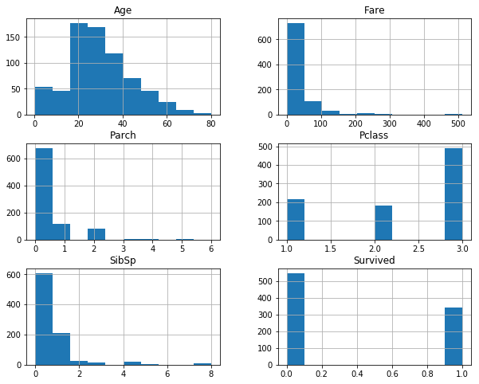

```python
df.hist(figsize=(10,8))
#%matplotlib inline used here to show graph in notebook next to code
```

```python
df.info()
```

```
<class 'pandas.core.frame.DataFrame'>
RangeIndex: 891 entries, 0 to 890
Data columns (total 9 columns):
Survived    891 non-null int64
Pclass      891 non-null int64
Sex         891 non-null object
Age         714 non-null float64
SibSp       891 non-null int64
Parch       891 non-null int64
Ticket      891 non-null object
Fare        891 non-null float64
Embarked    889 non-null object
dtypes: float64(2), int64(4), object(3)
memory usage: 62.7+ KB
```

plot the null values in Age with other column

```
array([[<matplotlib.axes._subplots.AxesSubplot object at 0x117e96d68>,
        <matplotlib.axes._subplots.AxesSubplot object at 0x1184b46a0>]], dtype=object)
```

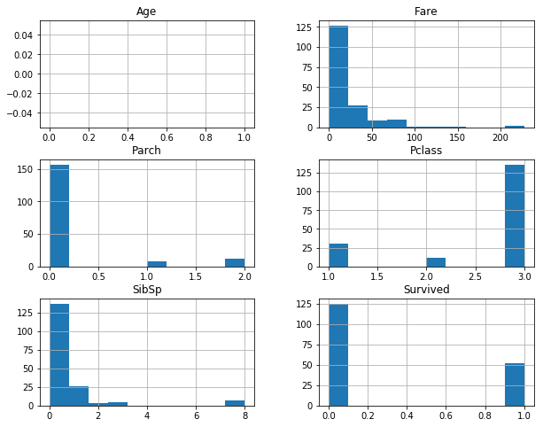

```python
df[df.Age.isnull()].hist(figsize=(10,8))
```

Data cleaning with null values.Replace the null values with mean of column

```python
df.fillna(df.mean(),inplace=True)
```

[output not shown]

```python
df.info()
```

```
<class 'pandas.core.frame.DataFrame'>
RangeIndex: 891 entries, 0 to 890
Data columns (total 9 columns):
Survived    891 non-null int64
Pclass      891 non-null int64
Sex         891 non-null object
Age         891 non-null float64
SibSp       891 non-null int64
Parch       891 non-null int64
Ticket      891 non-null object
Fare        891 non-null float64
Embarked    889 non-null object
dtypes: float64(2), int64(4), object(3)
memory usage: 62.7+ KB
```

There are two rows in Embarked which is null,drop that rows

```python
df[df.Embarked.isnull()]
```

|  | Survived | Pclass | Sex | Age | SibSp | Parch | Ticket | Fare | Embarked |
| --- | --- | --- | --- | --- | --- | --- | --- | --- | --- |
| 61 | 1 | 1 | female | 38.0 | 0 | 0 | 113572 | 80.0 | NaN |
| 829 | 1 | 1 | female | 62.0 | 0 | 0 | 113572 | 80.0 | NaN |

```python
df.dropna(inplace=True)
```

```python
df.info()
```

```
<class 'pandas.core.frame.DataFrame'>
Int64Index: 889 entries, 0 to 890
Data columns (total 9 columns):
Survived    889 non-null int64
Pclass      889 non-null int64
Sex         889 non-null object
Age         889 non-null float64
SibSp       889 non-null int64
Parch       889 non-null int64
Ticket      889 non-null object
Fare        889 non-null float64
Embarked    889 non-null object
dtypes: float64(2), int64(4), object(3)
memory usage: 69.5+ KB
```

# Exploring surivival of titanic

```python
survived=df.Survived==True
died=df.Survived==False
```

```python
survived.shape
```

```
(889,)
```

```python
df.Fare[survived].mean()
```

```
48.209498235294106
```

```python
df.Fare[died].mean()
```

```
22.117886885245877
```

Plot histogram of survived and dead based on Fare

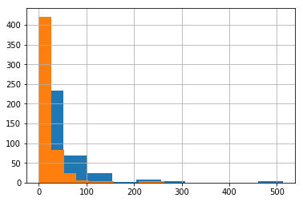

```python
df.Fare[survived].hist()
df.Fare[died].hist()
```

plot the graph with label ,transparency(alpha) and bins(range that divide the value in series of interval)

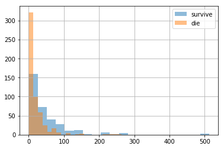

```python
df.Fare[survived].hist(alpha=0.5,bins=20,label='survive')
df.Fare[died].hist(alpha=0.5,bins=20,label='die')
plt.legend()# show the label
```

Survival accorind to their ticket class (Firstclass=1 SecondClass=2 ThirdClass=3)

```python
df.groupby('Pclass').Survived.mean()
```

```
Pclass
1    0.626168
2    0.472826
3    0.242363
Name: Survived, dtype: float64
```

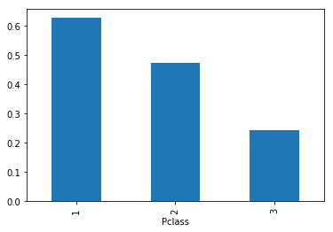

```python
df.groupby('Pclass').Survived.mean().plot(kind='bar')
```

Plot the chance of survival based on Age

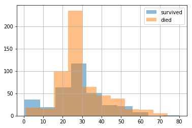

```python
df.Age[survived].hist(alpha=0.5,label='survived')
df.Age[died].hist(alpha=0.5,label='died')
plt.legend()
```

Plot the chance of survival based on Sex

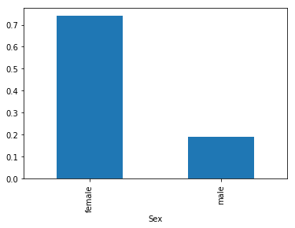

```python
df.groupby('Sex').Survived.mean().plot(kind='bar')
```

Ticket class distribution based on Sex ratio

```python
df.groupby('Sex')['Pclass'].value_counts()
```

```
Sex     Pclass
female  3         144
        1          92
        2          76
male    3         347
        1         122
        2         108
Name: Pclass, dtype: int64
```

Who has spend more on fare female or male?

```python
df.query('Sex=="female"')['Fare'].median(),df.query('Sex=="male"')['Fare'].median()
#Since it is one line it will print both the result
```

```
(23.0, 10.5)
```

Survival based on Sex and ticket class

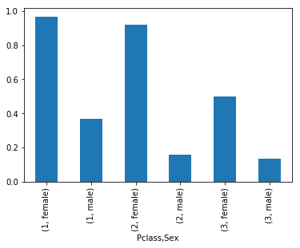

```python
df.groupby(['Pclass','Sex']).Survived.mean().plot(kind='bar')
```

What are the chanced of survival,if they are with siblings

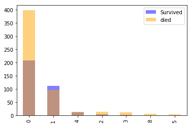

```python
df.SibSp[survived].value_counts().plot(kind='bar',alpha=0.5,color='blue',label='Survived')
df.SibSp[died].value_counts().plot(kind='bar',alpha=0.5,color='orange',label='died')
plt.legend()
```

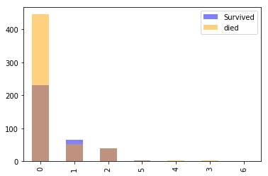

```python
df.Parch[survived].value_counts().plot(kind='bar',alpha=0.5,color='blue',label='Survived')
df.Parch[died].value_counts().plot(kind='bar',alpha=0.5,color='orange',label='died')
plt.legend()
```

What are the chanced of survival based on Embarked(go on a ship or aircraft)?

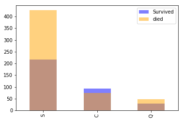

```python
df.Embarked[survived].value_counts().plot(kind='bar',alpha=0.5,color='blue',label='Survived')
df.Embarked[died].value_counts().plot(kind='bar',alpha=0.5,color='orange',label='died')
plt.legend()
```